# Work Document

Julian Morales, Andrea Vasquez

2026-11-22

## 311 rodent complaints, 2018 - 2026

The data come from the NYC Open Data API, read with `GET()`, so anyone can rerun this file. The API returns only 1,000 rows by default, so we raise `$limit` and download one year at a time. 311 is split into two datasets: `76ig-c548` covers 2010-2019 and `erm2-nwe9` covers 2020 to present. We keep every complaint with complaint type “Rodent” and choose the descriptor (“Rat Sighting”) later, so no category is lost.

### Function to download dataset

```r
get_rodent_year = function(dataset_id, yr) {

  Sys.sleep(5)

  GET(
    paste0("https://data.cityofnewyork.us/resource/", dataset_id, ".csv"),
    query = list(
      "$select" = "unique_key, created_date, descriptor, community_board, borough, location_type, latitude, longitude",
      "$where" = paste0(
        "complaint_type = 'Rodent' AND created_date >= '", yr,
        "-01-01T00:00:00' AND created_date < '", yr + 1, "-01-01T00:00:00'"
      ),
      "$limit" = "300000"
    )
  ) |>
    content("text") |>
    read_csv(col_types = cols(.default = "c"))
}
```

### Data import

```r
if (!file.exists("data/rodent_311.csv")) {

  dir.create("data", showWarnings = FALSE)

  rodent_2018_2019 =
    map(2018:2019, \(yr) get_rodent_year("76ig-c548", yr)) |>
    bind_rows()

  rodent_2020_2026 =
    map(2020:2026, \(yr) get_rodent_year("erm2-nwe9", yr)) |>
    bind_rows()

  rodent_raw = bind_rows(rodent_2018_2019, rodent_2020_2026)

  write_csv(rodent_raw, "data/rodent_311.csv")
}
```

### Data cleaning

311 writes community districts like “09 MANHATTAN”, while PLUTO uses codes like 109. We convert them to PLUTO’s format so the two datasets can be joined. We also drop the current month, which is incomplete.

```r
last_full_month = lubridate::floor_date(Sys.Date(), "month")

nyc_rodent =
  read_csv("data/rodent_311.csv", col_types = cols(.default = "c")) |>
  janitor::clean_names() |>
  distinct(unique_key, .keep_all = TRUE) |>
  separate(
    community_board,
    into = c("board_num", "board_boro"),
    sep = " ",
    extra = "merge",
    remove = FALSE
  ) |>
  mutate(
    created_date = as.Date(created_date),
    year = lubridate::year(created_date),
    month = lubridate::floor_date(created_date, "month"),
    board_num = as.numeric(board_num),
    boro_code = case_when(
      board_boro == "MANHATTAN" ~ 100,
      board_boro == "BRONX" ~ 200,
      board_boro == "BROOKLYN" ~ 300,
      board_boro == "QUEENS" ~ 400,
      board_boro == "STATEN ISLAND" ~ 500
    ),
    community_district = boro_code + board_num,
    latitude = as.numeric(latitude),
    longitude = as.numeric(longitude)
  ) |>
  filter(month < last_full_month) |>
  select(
    unique_key, created_date, year, month, descriptor,
    borough, community_board, community_district, location_type, latitude, longitude
  )

## view dataset

view(nyc_rodent)
```

The dataset has 308042 rodent complaints from 2018-01-01 to 2026-10-31.

### Type of rodent complaint

```r
complaint_type =
  nyc_rodent |>
  group_by(year, descriptor) |>
  summarize(
    n = n_distinct(unique_key),
    .groups = "drop"
  ) |>
  arrange(year)

complaint_type |>
  pivot_wider(
    names_from = descriptor,
    values_from = n,
    values_fill = 0
  ) |>
  knitr::kable()
```

| year | Condition Attracting Rodents | Mouse Sighting | Rat Sighting | Signs of Rodents | Rodent Bite - PCS Only |
| --- | --- | --- | --- | --- | --- |
| 2018 | 7430 | 4561 | 17353 | 3186 | 0 |
| 2019 | 7115 | 4278 | 16808 | 3438 | 5 |
| 2020 | 5624 | 3162 | 16262 | 2522 | 13 |
| 2021 | 7111 | 3398 | 25012 | 3272 | 16 |
| 2022 | 6697 | 3473 | 26500 | 4440 | 11 |
| 2023 | 7748 | 3144 | 25452 | 5389 | 15 |
| 2024 | 6883 | 2047 | 25191 | 5604 | 1 |
| 2025 | 6030 | 1398 | 19896 | 3988 | 0 |
| 2026 | 5509 | 794 | 15732 | 1534 | 0 |

Note: 2026 is not a full year, so its totals are lower than other years.

### Type of rodent complaint plot

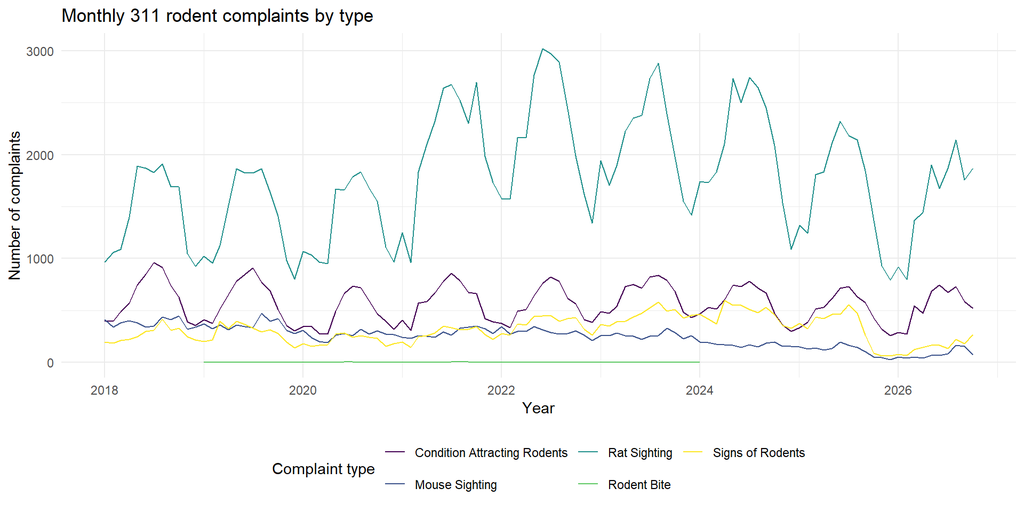

```r
nyc_rodent |>
  mutate(descriptor = recode(descriptor, "Rodent Bite - PCS Only" = "Rodent Bite")) |>
  count(month, descriptor) |>
  ggplot(aes(x = month, y = n, color = descriptor)) +
  geom_line() +
  labs(
    title = "Monthly 311 rodent complaints by type",
    x = "Year",
    y = "Number of complaints",
    color = "Complaint type"
  ) +
  guides(color = guide_legend(nrow = 2))
```

### Rat sightings

Rat sightings are our main outcome. The dashed lines mark when each trash bin rule took effect, according to the NYC Department of Sanitation (DSNY).

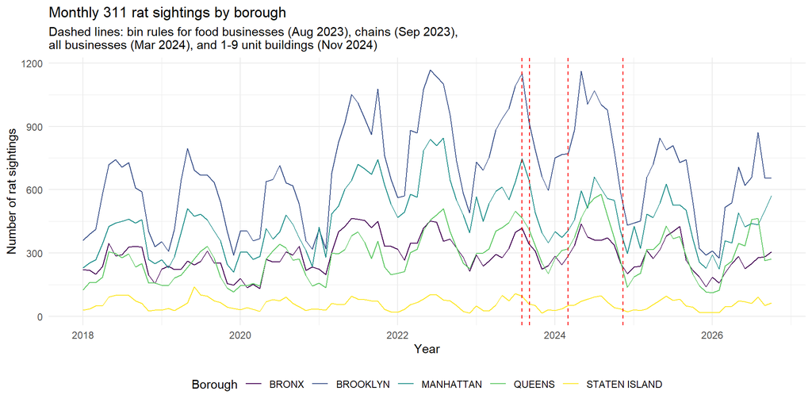

```r
rat_sightings =
  nyc_rodent |>
  filter(descriptor == "Rat Sighting")

bin_rules =
  tibble(
    date = as.Date(c("2023-08-01", "2023-09-05", "2024-03-01", "2024-11-12")),
    rule = c("Food businesses", "Chain businesses", "All businesses", "1-9 unit buildings")
  )

rat_sightings |>
  filter(borough != "Unspecified", !is.na(borough)) |>
  count(borough, month) |>
  ggplot(aes(x = month, y = n, color = borough)) +
  geom_line() +
  geom_vline(
    data = bin_rules,
    aes(xintercept = date),
    linetype = "dashed",
    color = "red"
  ) +
  labs(
    title = "Monthly 311 rat sightings by borough",
    subtitle = "Dashed lines: bin rules for food businesses (Aug 2023), chains (Sep 2023),\nall businesses (Mar 2024), and 1-9 unit buildings (Nov 2024)",
    x = "Year",
    y = "Number of rat sightings",
    color = "Borough"
  )
```

### Seasonal patterns in rat sightings by borough

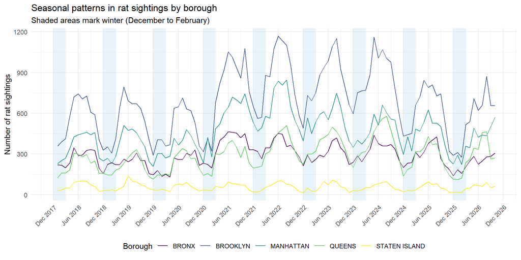

```r
winters =
  tibble(
    start = as.Date(paste0(2017:2025, "-12-01")),
    end = as.Date(paste0(2018:2026, "-03-01"))
  )

rat_sightings |>
  filter(borough != "Unspecified", !is.na(borough)) |>
  count(borough, month) |>
  ggplot(aes(x = month, y = n, color = borough)) +
  geom_rect(
    data = winters,
    aes(xmin = start, xmax = end, ymin = -Inf, ymax = Inf),
    inherit.aes = FALSE,
    fill = "lightblue",
    alpha = 0.3
  ) +
  geom_line() +
  scale_x_date(date_breaks = "6 months", date_labels = "%b %Y") +
  labs(
    title = "Seasonal patterns in rat sightings by borough",
    subtitle = "Shaded areas mark winter (December to February)",
    x = NULL,
    y = "Number of rat sightings",
    color = "Borough"
  ) +
  theme(axis.text.x = element_text(angle = 45, hjust = 1))
```

### Rat sighting’s by Location type

```r
# Rat sightings detailed by specific location type
rat_location_summary =
  nyc_rodent |>
  filter(descriptor == "Rat Sighting") |>
  mutate(
    year = lubridate::year(created_date)
  ) |>
  filter(year >= 2018, year <= 2026) |>
  group_by(year, location_type) |>
  summarize(
    n = n_distinct(unique_key),
    .groups = "drop"
  )

location_groups =
  rat_location_summary |>
  distinct(location_type) |>
  arrange(location_type) |>
  mutate(
    plot_group = ceiling(row_number() / 12)
  )

rat_location_split =
  rat_location_summary |>
  left_join(location_groups, by = "location_type")

plot_locations = function(group_number) {

  rat_location_split |>
    filter(plot_group == group_number) |>
    ggplot(aes(
      x = year,
      y = n,
      group = location_type
    )) +
    geom_line(
      color = "steelblue",
      linewidth = 0.7
    ) +
    geom_point(
      color = "steelblue",
      size = 1.5
    ) +
    facet_wrap(
      ~location_type,
      scales = "free_y",
      ncol = 2,
      labeller = label_wrap_gen(width = 25)
    ) +
    scale_x_continuous(
      breaks = seq(2018, 2026, 2)
    ) +
    scale_y_continuous(
      labels = scales::label_comma()
    ) +
    labs(
      title = paste("Annual Rat Sightings by Location Type - Group", group_number),
      x = "Year",
      y = "Number of Reported Rat Sightings"
    ) +
    theme_minimal() +
    theme(
      strip.text = element_text(size = 9, face = "bold"),
      axis.text.x = element_text(size = 8),
      axis.text.y = element_text(size = 8),
      panel.spacing = grid::unit(1.5, "lines"),
      plot.title = element_text(size = 13, face = "bold")
    )
}
```

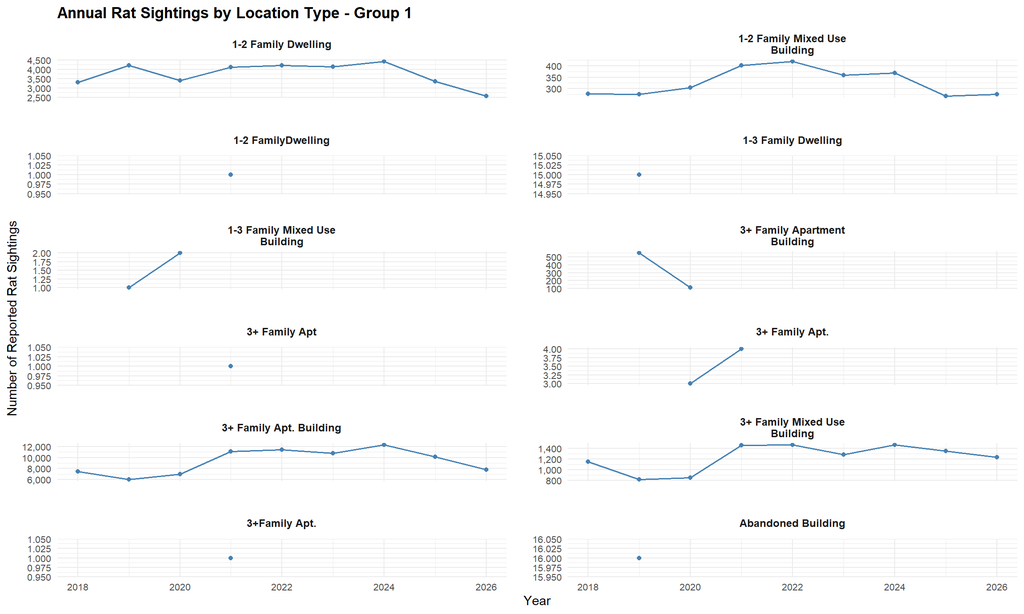

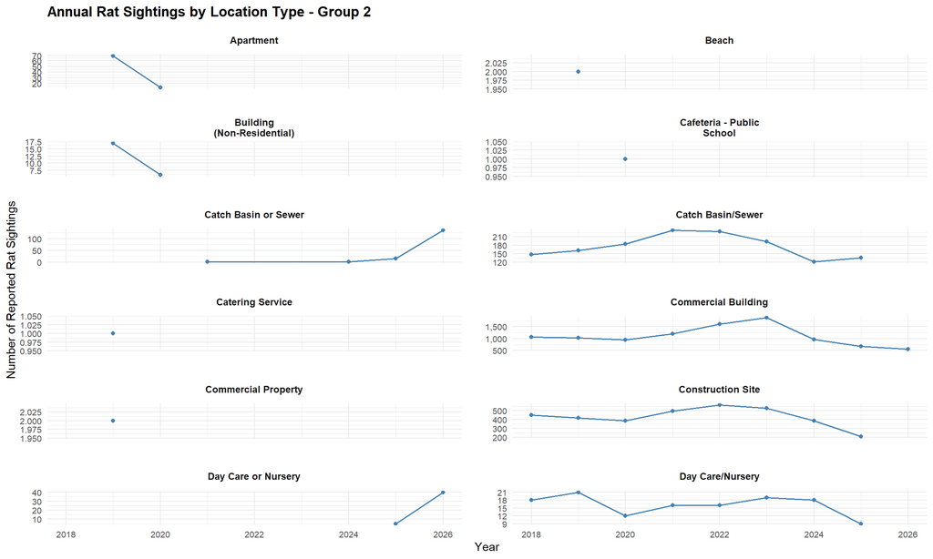

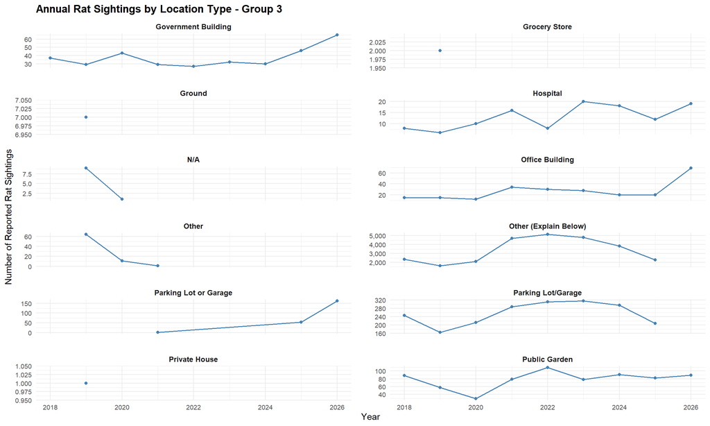

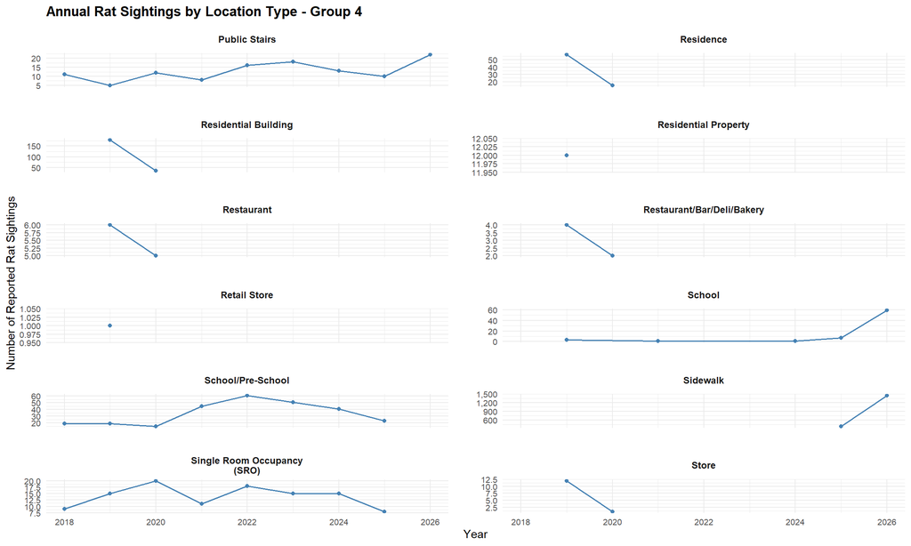

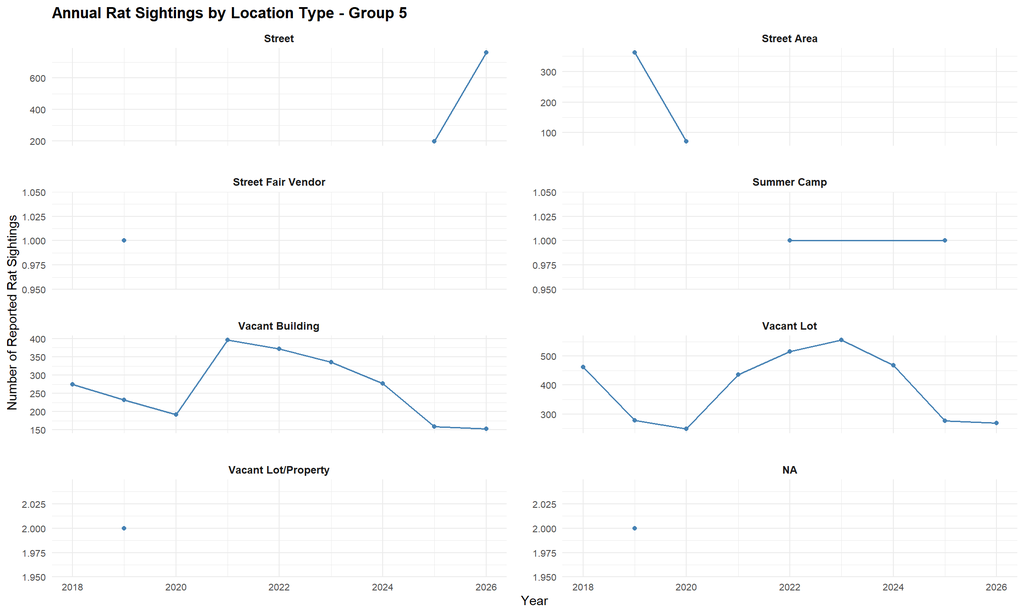

```r
for (i in sort(unique(rat_location_split$plot_group))) {
  print(plot_locations(i))
}
```

****Note for team:** We should discuss whether we want to recategorize the existing location types into groups that align with the NYC trash bin regulations. This would allow us to examine changes in reported rat sightings for different building types before and after each regulation takes effect. We would also need to establish clear criteria for defining each group, particularly for locations that do not clearly fit into a specific category (e.g., whether to include vacant lots/properties, whether schools and hospitals qualify as businesses, and how to classify residential buildings with unspecified unit counts). We should also determine how to handle locations that cannot be reliably classified under any of the regulations.**

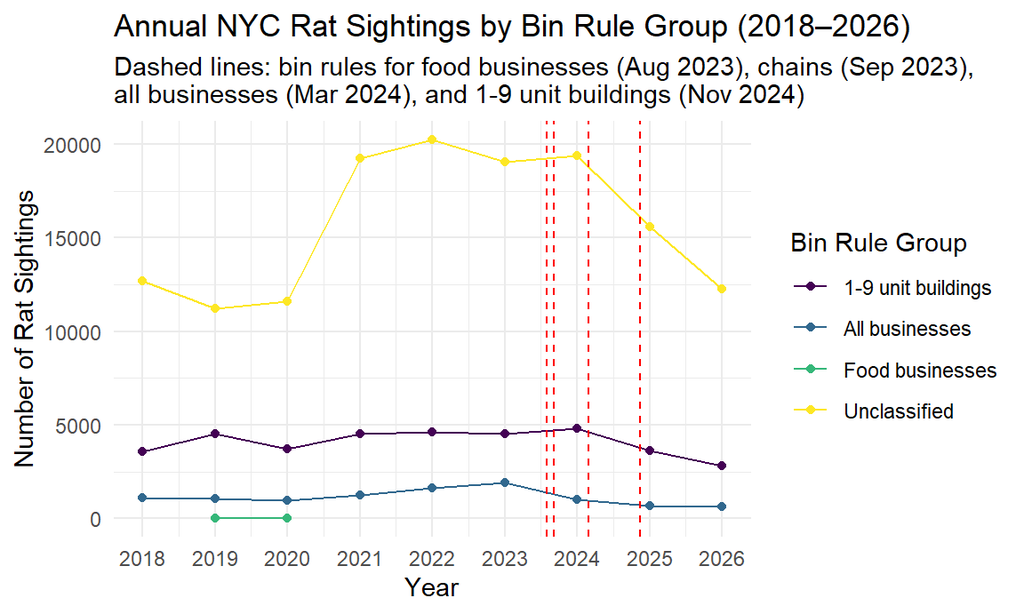

```r
rat_location_grouped =
  nyc_rodent |>
  filter(descriptor == "Rat Sighting") |>
  mutate(
    bin_group = case_when(
      location_type %in% c(
        "Restaurant",
        "Restaurant/Bar/Deli/Bakery",
        "Grocery Store",
        "Catering Service"
      ) ~ "Food businesses",

      location_type %in% c(
        "Commercial Building",
        "Commercial Property",
        "Retail Store",
        "Store",
        "Office Building"
      ) ~ "All businesses",

      location_type %in% c(
        "1-2 Family Dwelling",
        "1-2 FamilyDwelling",
        "1-3 Family Dwelling",
        "1-2 Family Mixed Use Building",
        "1-3 Family Mixed Use Building",
        "Private House"
      ) ~ "1-9 unit buildings",

      TRUE ~ "Unclassified"
    )
  )

rat_group_summary =
  rat_location_grouped |>
  mutate(
    year = lubridate::year(created_date)
  ) |>
  filter(year >= 2018, year <= 2026) |>
  group_by(year, bin_group) |>
  summarize(
    n = n_distinct(unique_key),
    .groups = "drop"
  )

bin_rules =
  tibble(
    date = as.Date(c("2023-08-01", "2023-09-05", "2024-03-01", "2024-11-12")),
    rule = c("Food businesses", "Chain businesses", "All businesses", "1-9 unit buildings")
  )

rat_group_plot =
  rat_group_summary |>
  mutate(
    year_date = as.Date(paste0(year, "-01-01"))
  ) |>
  ggplot(aes(
    x = year_date,
    y = n,
    color = bin_group,
    group = bin_group
  )) +
  geom_point() +
  geom_line() +
  geom_vline(
    data = bin_rules,
    aes(xintercept = date),
    linetype = "dashed",
    color = "red"
  ) +
  scale_x_date(
    date_breaks = "1 year",
    date_labels = "%Y"
  ) +
  labs(
    title = "Annual NYC Rat Sightings by Bin Rule Group (2018–2026)",
    subtitle = "Dashed lines: bin rules for food businesses (Aug 2023), chains (Sep 2023),\nall businesses (Mar 2024), and 1-9 unit buildings (Nov 2024)",
    x = "Year",
    y = "Number of Rat Sightings",
    color = "Bin Rule Group"
  ) +
  theme_minimal()

rat_group_plot
```

### City mapping of Rat sightings

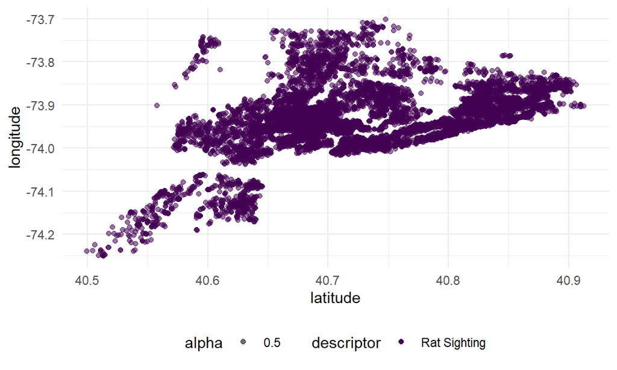

```r
#General Map Framework
#2018 map
nyc_rat_2018 =
  nyc_rodent |>
  select(year, descriptor, latitude, longitude) |>
  filter(
    !is.na(year),
    !is.na(descriptor),
    !is.na(latitude),
    !is.na(longitude),
    year == "2018",
    latitude != 0,
    longitude != 0,
    descriptor == "Rat Sighting"
  )

nyc_rat_2018 |>
  ggplot(aes(x = latitude, y = longitude, type = "scatter", mode = "markers",
    color = descriptor, alpha = 0.5)) +
  geom_point()
```

```r
nyc_rat_2018 |>
  plot_ly(x = ~latitude, y = ~longitude, type = "scatter", mode = "markers",
    color = ~descriptor, alpha = 0.5)
```

[interactive chart not shown]

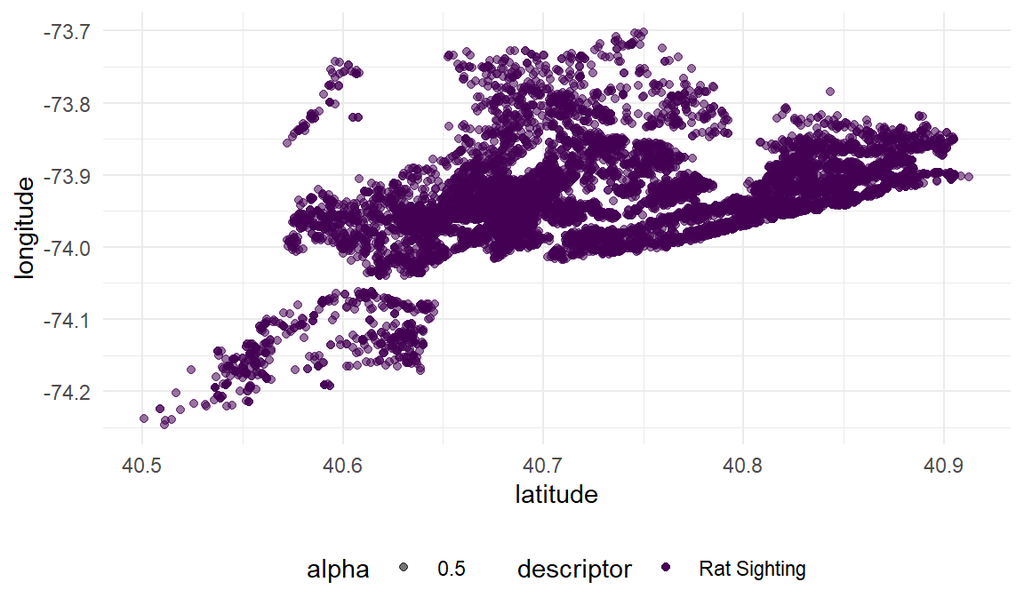

```r
# 2026 map
nyc_rat_2026 =
  nyc_rodent |>
  select(year, descriptor, latitude, longitude) |>
  filter(
    !is.na(year),
    !is.na(descriptor),
    !is.na(latitude),
    !is.na(longitude),
    year == "2026",
    latitude != 0,
    longitude != 0,
    descriptor == "Rat Sighting"
  )

nyc_rat_2026 |>
  ggplot(aes(x = latitude, y = longitude, type = "scatter", mode = "markers",
    color = descriptor, alpha = 0.5)) +
  geom_point()
```

```r
nyc_rat_2026 |>
  plot_ly(x = ~latitude, y = ~longitude, type = "scatter", mode = "markers",
    color = ~descriptor, alpha = 0.5)
```

[interactive chart not shown]

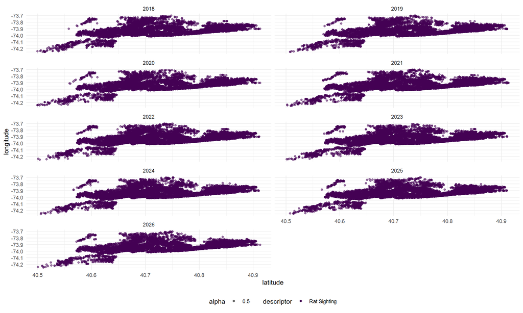

```r
nyc_rat_allmap =
  nyc_rodent |>
  select(year, descriptor, latitude, longitude) |>
  filter(
    !is.na(year),
    !is.na(descriptor),
    !is.na(latitude),
    !is.na(longitude),
    latitude != 0,
    longitude != 0,
    descriptor == "Rat Sighting"
  ) |>
  group_by(year) |>
  ggplot(aes(x = latitude, y = longitude, type = "scatter", mode = "markers",
    color = descriptor, alpha = 0.5)) +
  geom_point() +
  facet_wrap(.~year, ncol = 2)

nyc_rat_allmap
```

### Old 311 data code